# Features of Probability Distributions

## Contents and Goals

- Get to know the basic features of probability distributions
  - Mean / Expected Value
  - Variance and Standard Deviation
  - Covariance and Correlation
  - Standardisation
- Learn how they work
- Learn how we can manipulate them

These features are the **building blocks of statistics**. Understanding how they work helps us to understand theoretical proofs.

They are useful to understand the concepts of (not exclusively) **Estimation**, **Hypothesis Tests** and **Regression**

## Central Tendency: The Expected Value

The most commonly used feature of a probability distribution is the *expected value*. It is calculated as a weighted average of the random variable.

\[ \mathbb{E}[X] = \sum x_i f(x_i) \]

*The expected value is the value from a probability distribution, for which the probabilities of another value being greater or smaller than it are exactly equal.*

For example, we simulate a random variable \(R\) from a standard normal distribution. First, we simulate the variable and draw a histogram with the arithmetic mean:

```r
set.seed(1337) #seed for reproducibility
data <- data.frame(R = rnorm(n = 1000000))
```

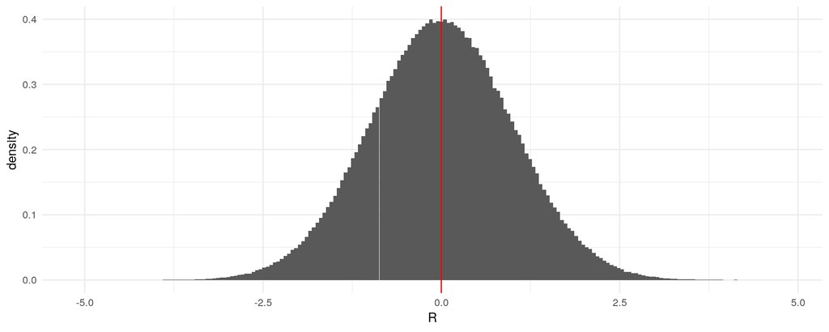

- It looks like the area to the left of the mean is the same size at the area on the right side. Let's check that:

```r
A <- numeric() # Variable for storing the area sizes

A[1] <- (sum (abs (data$R[data$R < mean(data$R)]))) /sum(abs(data$R)) # Left area in percent
A[2] <- (sum (abs (data$R[data$R > mean(data$R)]))) /sum(abs(data$R)) # Right area in percent

print(A)
```

```
## [1] 0.5007953 0.4992047
```

- Notice that since we're in a simulation context, the areas are not *exactly* the same.

## Useful Rules for Expected Values

For any constants \(a\) and \(b\) and a random variable \(X\), the following rules apply:

- The expected value of a constant is the constant \[ \mathbb{E}[c] = c \]
- The expected value of a linear function of a random variable is the linear function of the expected value of the variable \[ \mathbb{E}[aX+b] = a\mathbb{E}[X] + b\]
- The expected value of a sum of random variables is the sum of the expected values of these random variables: \[ \mathbb{E}\left[ \sum_{i=1}^n a_iX_i \right] = \sum_{i=1}^n \mathbb{E}[a_iX_i] = \sum_{i=1}^n a_i \mathbb{E}[X_i] \]
- For a variable \(Y\) that is independent of \(X\) it holds that: \[ \mathbb{E}[XY] = \mathbb{E}[X] \mathbb{E}[X] \]
- The population mean is often denoted by \(\mu\) or \(\mu_X\) instead of \(\mathbb{E}[X]\)

## Variablity: Variance and Standard Deviation

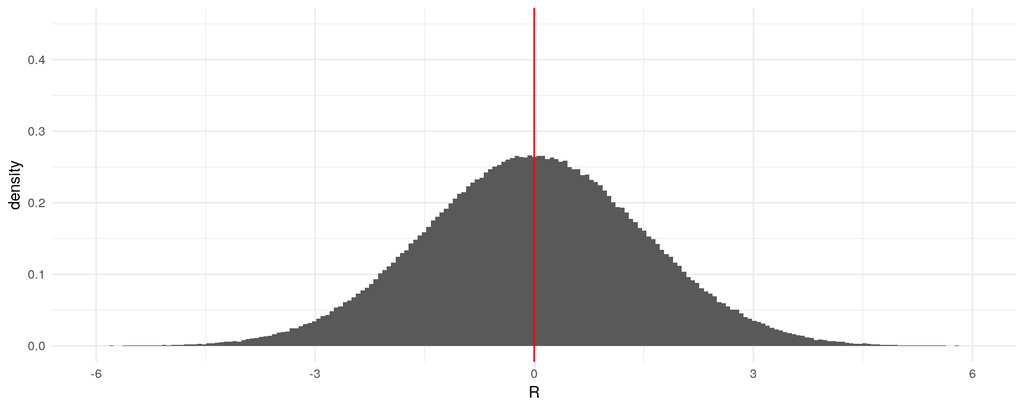

## Variablity: Variance and Standard Deviation

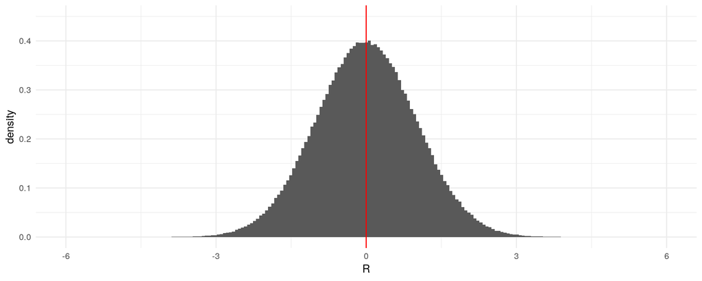

## Variablity: Variance and Standard Deviation

- The variance measures how far a variable *spreads around the mean*

You can see this notion of *distance from the mean* in the definition of the variance:

\[ Var[X] = \mathbb{E} \left[ \left( X - \mathbb{E} [X] \right) ^2 \right] \]

The deviation from the expected value \((X - \mathbb{E}[X])\) is squared in order to prevent perfect cancellation of deviations, since: \[\mathbb{E} \left[(X - \mathbb{E}[X]) \right] = \mathbb{E}[X] - \mathbb{E}[X] = 0\]

## Useful Rules for Variances

For any constants \(a\) and \(b\) and a random variable \(X\), the following rules apply:

- Alternative representation \[ Var[X] = \mathbb{E} \left[ X^2 \right] - \mathbb{E}[X]^2 \]
- Variance of a constant is zero: \[ Var[c] = 0 \]
- Variance of a linear combination: \[ Var[aX+b] = a^2 Var[X] \]

## Useful Rules for Variances

- The variance of a sum of random variables is the sum of the evariance, given independence: \[ Var\left[ a_i \sum_{i=1}^n X_i \right] = \sum_{i=1}^n Var[a_i X_i] = \sum_{i=1}^n a_i^2 Var[X_i] \]
- The population variance is often denoted by \(\sigma^2\) or \(\sigma_X^2\) instead of \(Var[X]\).

## The Standard Deviation

- If we change the unit of measurement of \(X\) by \(a = 1000\), the variance scales quadratically by \(a^2 = 1000 * 1000\)
- To avoid this, we calculate the standard deviation, which scales linearly with \(a\):

\[ sd[X] = + \sqrt{Var[X]} \] For any constants \(a\) and \(b\) and a random variable \(X\), it has the following useful properties: - Standard deviation of a linear combination: \[ sd[a X + b] = |a| sd[X] \]

- The standard deviation is often denoted by \(\sigma\) or \(\sigma_X\) instead of \(sd[X]\).

## Standardisation of Variables

Using the properties of the expected value and variance, we can transform any variable to a standardised variable with mean 0 and standard deviation 1: \[ Z := \frac{X-\mu}{\sigma} \]

## Standardisation of Variables: Example

We can demonstrate this with a short simulation. In the following we simulate a random variable \(X\) from a normal distribution, that has mean \(3\) and standard deviation \(1.5\)

```r
set.seed(1337) #seed for reproducibility
data_st <- data.frame(R = rnorm(n = 10000, mean = 3, sd = 1.5))
```

## Standardisation of Variables: Example

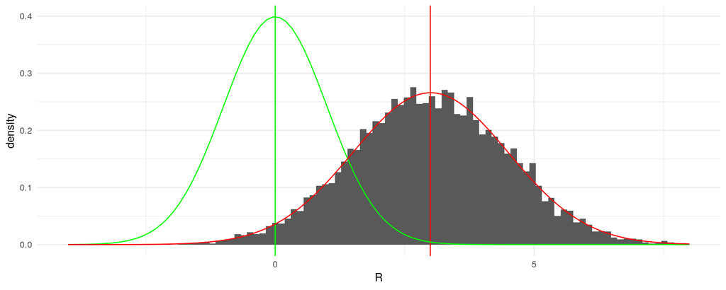

## Standardisation: Subtracting the mean

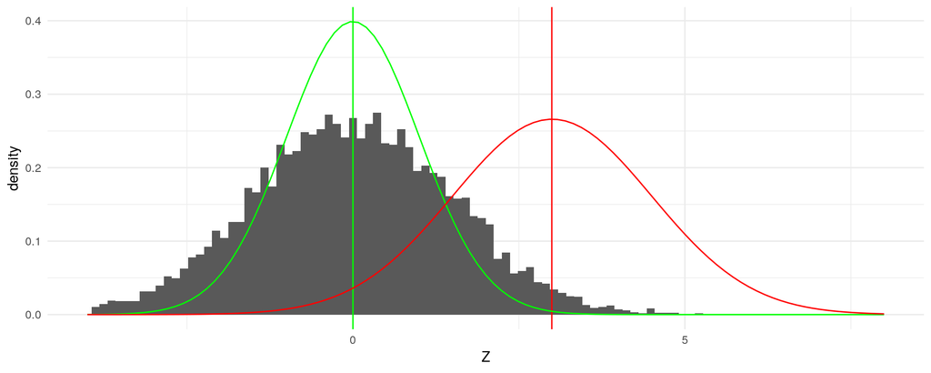

## Dividing by the standard deviation

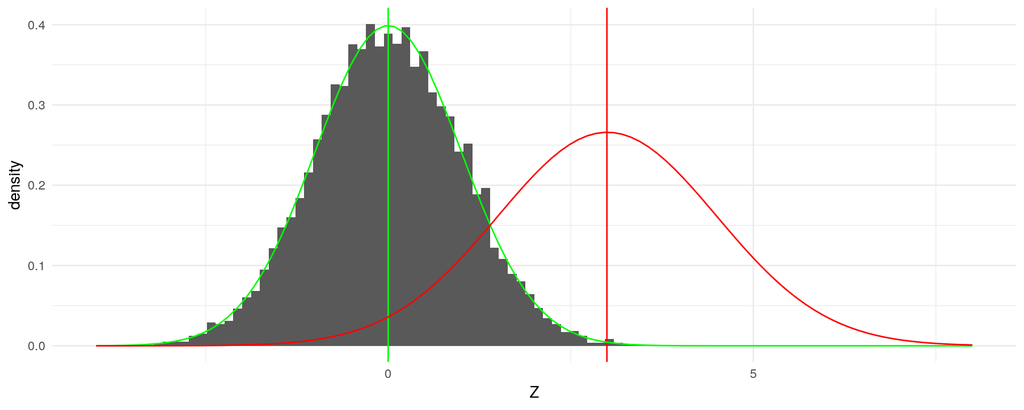

## Association: Covariance and Correlation

The covariance captures the joint variation of two random variables. It allows us to get a sense of the relationship of them, e.g. \(X\) is always high when \(Y\) is. This can be visualised graphically:

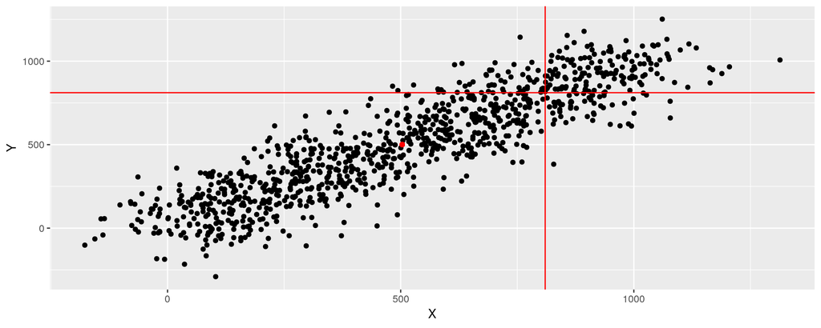

## Association: Covariance and Correlation

- Deviation of \(X\) (vertical line) from its mean (red dot) is highwhen the deviation of \(Y\) (horizontal line) is high
- Expressing this relation of deviations from the mean mathematically yields us the formula of the covariance:

\[ Cov[X,Y] = \mathbb{E} \left[ (X - \mathbb{E}[X]) (Y - \mathbb{E}{Y} ) \right] \]

## Useful Rules for Covariances

For any constants \(a\) and \(b\) and random variables \(X\), and \(Y\) the following rules apply:

- Alternative representations: \[ \begin{aligned} Cov[X,Y] &= \mathbb{E}[XY] - \mathbb{E}[X] \mathbb{E}[Y] \\ &= \mathbb{E}[(X -\mathbb{E}[X])Y] \\ &= \mathbb{E}[X (Y -\mathbb{E}[Y])] \\ \end{aligned}\]
- Covariance given independence of \(X\) and \(Y\): \[ \begin{aligned} Cov[X,Y] &= \mathbb{E}[XY] - \mathbb{E}[X] \mathbb{E}[Y] \\ &= 0 & \text{since } \mathbb{E}[XY] = \mathbb{E}[X] \mathbb{E}[X] \end{aligned}\]

## Useful Rules for Covariances

- Variance of linear combinations: \[ Cov[a_1 X + b_1, a_2Y + b_2] = a_1 a_2 Cov[X,Y]\]
- The boundary of the covariance of two random variables (its most extreme value) is given by the product of their standard deviations. This is also called the *Cauchy-Schwartz Inequality*: \[ |Cov[X,Y]| \leq sd[X] sd[Y] \]
- The population covariance is usually denoted by \(\sigma_{XY}\) instead of \(Cov[X,Y]\)

## The Correlation Coefficient

- Variance and standard deviation are both dependent on their units of measurement.
- Using the *Cauchy-Schwartz Inequality* we can normalise the variance:

\[ Corr[X,Y] = \frac{Cov[X,Y]}{sd[X] sd[Y]} = \frac{\sigma_{XY}}{\sigma_X \sigma_Y}\]

- The population correlation coefficient is usually denoted as \(\rho\) or \(\rho_{XY}\) instead of \(Corr[X,Y]\)